# Logistic Regression Notes

Jeffrey D Walker, PhD

10/10/2017

# Set Up

```r
library(tidyverse)
library(lubridate)
library(caret)
library(pROC)

models <- readRDS("../data/model-data.rds")
df <- models$ls$MYSTIC_ENT
```

```r
table(df$exceedance_class)
```

```
##
## yes  no
##  11  93
```

# Dataset Partition

Use `createDataPartition()` to create stratified random sample of entire dataset.

```r
set.seed(1)
training_rows <- createDataPartition(df$exceedance_class, p = 0.80, list = FALSE)
df_train <- df[training_rows, ]
df_test <- df[-training_rows, ]

c(Train = nrow(df_train), Test = nrow(df_test))
```

```
## Train  Test
##    84    20
```

```r
table(df_train$exceedance_class)
```

```
##
## yes  no
##   9  75
```

```r
table(df_test$exceedance_class)
```

```
##
## yes  no
##   2  18
```

# glm Model

```r
m_glm <- glm(exceedance ~ precip_sum_p24hr_lag6hr, data = df_train, family = "binomial")
summary(m_glm)
```

```
##
## Call:
## glm(formula = exceedance ~ precip_sum_p24hr_lag6hr, family = "binomial",
##     data = df_train)
##
## Deviance Residuals:
##     Min       1Q   Median       3Q      Max
## -1.8224  -0.2048  -0.2048  -0.2048   2.6050
##
## Coefficients:
##                         Estimate Std. Error z value Pr(>|z|)
## (Intercept)              -3.8538     0.7641  -5.044 4.57e-07 ***
## precip_sum_p24hr_lag6hr   7.0716     1.8672   3.787 0.000152 ***
## ---
## Signif. codes:  0 '***' 0.001 '**' 0.01 '*' 0.05 '.' 0.1 ' ' 1
##
## (Dispersion parameter for binomial family taken to be 1)
##
##     Null deviance: 57.204  on 83  degrees of freedom
## Residual deviance: 26.934  on 82  degrees of freedom
## AIC: 30.934
##
## Number of Fisher Scoring iterations: 6
```

- Null deviance: deviance based on “Null” model (grand mean intercept only)
- Residual deviance: remaining deviance with full model

Can compute a “psuedo-R^2” value from ratio of deviance and null deviance (http://ethen8181.github.io/machine-learning/unbalanced/unbalanced.html)

```r
pseudo_r2 <- 1 - (summary(m_glm)$deviance / summary(m_glm)$null.deviance)
pseudo_r2
```

```
## [1] 0.5291552
```

### Prediction

Two types of prediction:

- `link`: returns log-odds
- `response`: returns probability (`exp(logodds) / (1 + exp(logodds))`)

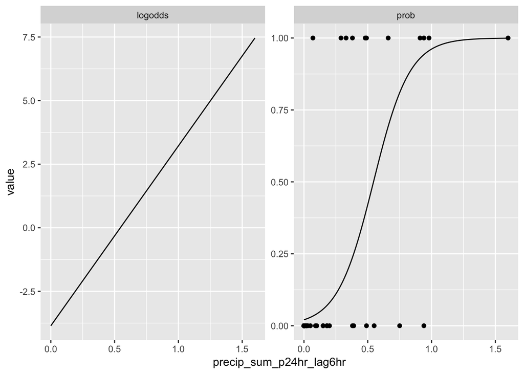

```r
m_glm_shape <- data_frame(precip_sum_p24hr_lag6hr = seq(0, max(df$precip_sum_p24hr_lag6hr), by = 0.01))
m_glm_shape$logodds <- predict(m_glm, newdata = m_glm_shape, type = "link")
# probability = exp(logodds) / (1 + exp(logodds))
m_glm_shape$prob <- predict(m_glm, newdata = m_glm_shape, type = "response")

m_glm_shape %>%
  gather(var, value, logodds, prob) %>%
  ggplot(aes(precip_sum_p24hr_lag6hr, value)) +
  geom_line() +
  geom_point(
    data = mutate(df, var = "prob"),
    aes(x = precip_sum_p24hr_lag6hr, y = exceedance)
  ) +
  facet_wrap(~ var, scales = "free_y")
```

### ROC Curve

ROC curve on training data.

```r
pred_prob <- predict(m_glm, newdata = df_train, type = "response") # same as fitted(m_glm)

roc <- roc(df_train$exceedance, pred_prob)
print(roc)
```

```
##
## Call:
## roc.default(response = df_train$exceedance, predictor = pred_prob)
##
## Data: pred_prob in 75 controls (df_train$exceedance 0) < 9 cases (df_train$exceedance 1).
## Area under the curve: 0.9667
```

Area under the curve: represents probability that a classifier will rank a randomly chosen positive observation higher than a randomly chosen negative observation. Independent of cutoff threshold.

```r
auc <- auc(roc)
print(auc)
```

```
## Area under the curve: 0.9667
```

Plot ROC curve

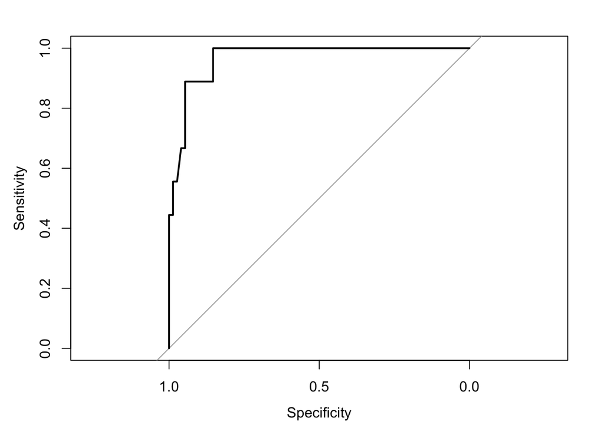

```r
plot(roc)
```

### Confusion Matrix

`confusionMatrix()` requires predictions to be 2-level factors. To create factors, must choose a cutoff value.

```r
pred_factor <- factor(if_else(pred_prob > 0.5, "yes", "no"), levels = levels(df_train$exceedance_class))
table(pred_factor)
```

```
## pred_factor
## yes  no
##   7  77
```

```r
confusionMatrix(
  data = pred_factor,
  reference = df_train$exceedance_class,
  positive = "yes"
)
```

```
## Confusion Matrix and Statistics
##
##           Reference
## Prediction yes no
##        yes   5  2
##        no    4 73
##
##                Accuracy : 0.9286
##                  95% CI : (0.851, 0.9733)
##     No Information Rate : 0.8929
##     P-Value [Acc > NIR] : 0.1914
##
##                   Kappa : 0.5862
##  Mcnemar's Test P-Value : 0.6831
##
##             Sensitivity : 0.55556
##             Specificity : 0.97333
##          Pos Pred Value : 0.71429
##          Neg Pred Value : 0.94805
##              Prevalence : 0.10714
##          Detection Rate : 0.05952
##    Detection Prevalence : 0.08333
##       Balanced Accuracy : 0.76444
##
##        'Positive' Class : yes
##
```

Metrics (http://www.dataschool.io/simple-guide-to-confusion-matrix-terminology/):

- `Accuracy`: Percent correct predictions (`TP + TN / Total N`)
- `No Information Rate`: Average proportion of `no` classes (`1 - mean(df_train$exceedance)`)
- `Kappa`: Agreement (`P_o - P_e / 1 - P_e`)
- `Sensitivity`: True positive rate, recall (`TP / TP + FN`)
- `Specificity`: True negative rate (`TN / TN + FP`)

Ref: [Measuring Performance of Classifiers](http://shahramabyari.com/2016/02/22/measuring-performance-of-classifiers/)

`Kappa` varies over `[-1, +1]` where `+1` is full agreement, `0` is no agreement, and `-1` is opposite agreement. Acceptable value `> 0.3 to 0.5`.

Can also use precision-recall summary, which is better for imbalanced classes

```r
confusionMatrix(
  data = pred_factor,
  reference = df_train$exceedance_class,
  positive = "yes",
  mode = "prec_recall"
)
```

```
## Confusion Matrix and Statistics
##
##           Reference
## Prediction yes no
##        yes   5  2
##        no    4 73
##
##                Accuracy : 0.9286
##                  95% CI : (0.851, 0.9733)
##     No Information Rate : 0.8929
##     P-Value [Acc > NIR] : 0.1914
##
##                   Kappa : 0.5862
##  Mcnemar's Test P-Value : 0.6831
##
##               Precision : 0.71429
##                  Recall : 0.55556
##                      F1 : 0.62500
##              Prevalence : 0.10714
##          Detection Rate : 0.05952
##    Detection Prevalence : 0.08333
##       Balanced Accuracy : 0.76444
##
##        'Positive' Class : yes
##
```

Metrics:

- `Precision`: percent of true positives out of all predicted positives (if predicts `yes`, how often correct?) (`TP / TP + FP`)
- `Recall`: percent of true positives out of all true positives (`TP / TP + FN`)

### Two Class Summary

The `twoClassSummary` function in `caret` package returns the ROC AUC, Sensitivity and Specificity. Requires data frame with 2-factor columns `pred`, `obs`, plus one colum for each factor containin the predicted probabilities.

```r
two_class_summary <- data_frame(
  yes = pred_prob
) %>%
  mutate(
    no = 1 - yes,
    pred = pred_factor,             # factor
    obs = df_train$exceedance_class # factor
  ) %>%
  as.data.frame() %>%
  twoClassSummary(data = ., lev = levels(.$obs), model = NULL)
print(two_class_summary)
```

```
##       ROC      Sens      Spec
## 0.9666667 0.5555556 0.9733333
```

Can also compute the combined distance of the sensitivity and specificity from 1 (useful for tuning model to maximize specificity/sensitivity).

```r
coords <- matrix(
  c(1, 1, two_class_summary["Spec"], two_class_summary["Sens"]),
  ncol = 2,
  byrow = TRUE
)
colnames(coords) <- c("Spec", "Sens")
rownames(coords) <- c("Best", "Current")
print(coords)
```

```
##              Spec      Sens
## Best    1.0000000 1.0000000
## Current 0.9733333 0.5555556
```

```r
print(c(two_class_summary, Dist = dist(coords)[1]))
```

```
##       ROC      Sens      Spec      Dist
## 0.9666667 0.5555556 0.9733333 0.4452437
```

### Optimizing Probability Thresholds

[Optimizing Probability Thresholds for Class Imbalances](http://appliedpredictivemodeling.com/blog/2014/2/1/lw6har9oewknvus176q4o41alqw2ow)

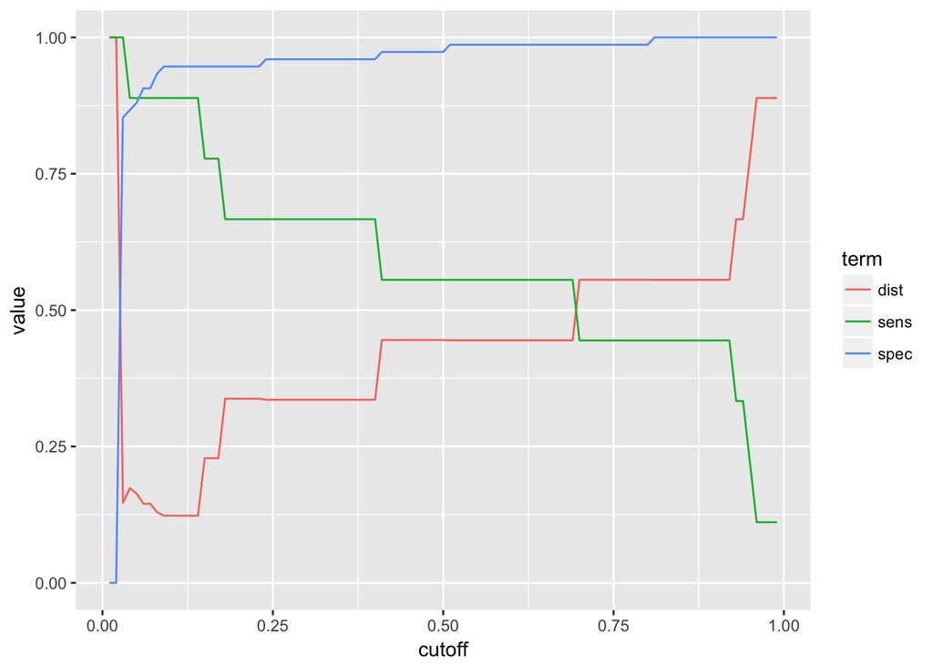

```r
df_cutoff <- data_frame(
    cutoff = seq(0.01, 0.99, 0.01)
  ) %>%
  mutate(
    tcs = map(cutoff, function (cutoff) {
      x <- data_frame(
        yes = pred_prob
      ) %>%
        mutate(
          no = 1 - yes,
          pred = factor(if_else(pred_prob > cutoff, "yes", "no"), levels = levels(df_train$exceedance_class)),
          obs = df_train$exceedance_class
        ) %>%
        as.data.frame()

      tcs <- twoClassSummary(data = x, lev = levels(x$obs), model = NULL)
      coords <- matrix(
        c(1, 1, tcs["Spec"], tcs["Sens"]),
        ncol = 2,
        byrow = TRUE
      )
      colnames(coords) <- c("Spec", "Sens")
      rownames(coords) <- c("Best", "Current")

      tcs_dist <- dist(coords)[1]

      data_frame(
        roc = tcs["ROC"],
        sens = tcs["Sens"],
        spec = tcs["Spec"],
        dist = tcs_dist
      )
    })
  ) %>%
  unnest(tcs)

df_cutoff %>%
  gather(term, value, -cutoff, -roc) %>%
  ggplot(aes(cutoff, value, color = term)) +
  geom_line()
```

Best cutoff is:

```r
best_cutoff <- mean(df_cutoff$cutoff[which(df_cutoff$dist == min(df_cutoff$dist))])
print(best_cutoff)
```

```
## [1] 0.115
```

With corresponding confusion matrix

```r
confusionMatrix(
  data = factor(if_else(pred_prob > best_cutoff, "yes", "no"), levels = levels(df_train$exceedance_class)),
  reference = df_train$exceedance_class,
  positive = "yes",
  mode = "prec_recall"
)
```

```
## Confusion Matrix and Statistics
##
##           Reference
## Prediction yes no
##        yes   8  4
##        no    1 71
##
##                Accuracy : 0.9405
##                  95% CI : (0.8665, 0.9804)
##     No Information Rate : 0.8929
##     P-Value [Acc > NIR] : 0.1023
##
##                   Kappa : 0.7287
##  Mcnemar's Test P-Value : 0.3711
##
##               Precision : 0.66667
##                  Recall : 0.88889
##                      F1 : 0.76190
##              Prevalence : 0.10714
##          Detection Rate : 0.09524
##    Detection Prevalence : 0.14286
##       Balanced Accuracy : 0.91778
##
##        'Positive' Class : yes
##
```

### Using Weights for Imbalance

[Handling Class Imbalance with R and Caret - An Introduction](http://dpmartin42.github.io/blogposts/r/imbalanced-classes-part-1)

Assign sample weights for fitting model.

```r
weight_yes <- (1/table(df_train$exceedance_class)["yes"]) * 0.5
weight_no <- (1/table(df_train$exceedance_class)["no"]) * 0.5
model_weights <- ifelse(
  df_train$exceedance_class == "yes",
  weight_yes,
  weight_no
)
c(yes = weight_yes, no = weight_no, ratio = weight_yes / weight_no, sum = sum(model_weights))
```

```
##     yes.yes       no.no   ratio.yes         sum
## 0.055555556 0.006666667 8.333333333 1.000000000
```

```r
m_glm_wt <- glm(exceedance ~ sqrt(precip_sum_p24hr_lag6hr), data = df_train, family = "binomial", weights = model_weights)
summary(m_glm_wt)
```

```
##
## Call:
## glm(formula = exceedance ~ sqrt(precip_sum_p24hr_lag6hr), family = "binomial",
##     data = df_train, weights = model_weights)
##
## Deviance Residuals:
##     Min       1Q   Median       3Q      Max
## -0.2298  -0.0240  -0.0240  -0.0240   0.3781
##
## Coefficients:
##                               Estimate Std. Error z value Pr(>|z|)
## (Intercept)                     -3.120      6.526  -0.478    0.633
## sqrt(precip_sum_p24hr_lag6hr)    8.153     14.927   0.546    0.585
##
## (Dispersion parameter for binomial family taken to be 1)
##
##     Null deviance: 1.3863  on 83  degrees of freedom
## Residual deviance: 0.4707  on 82  degrees of freedom
## AIC: 4
##
## Number of Fisher Scoring iterations: 6
```

**Does not work!**

# `caret` Package

### Train Control

10-fold Cross-validation

```r
trControl <- trainControl(
  method = "cv",
  number = 10,
  classProbs = TRUE,
  summaryFunction = twoClassSummary,
  returnResamp = "all"
)
```

```r
m_glm_cv10 <- train(
  exceedance_class ~ precip_sum_p24hr_lag6hr,
  data = df_train,
  method = "glm",
  family = "binomial",
  metric = "ROC", # ["ROC", "Spec", "Sens"] <- returned from twoClassSummary
  trControl = trControl
)
m_glm_cv10
```

```
## Generalized Linear Model
##
## 84 samples
##  1 predictor
##  2 classes: 'yes', 'no'
##
## No pre-processing
## Resampling: Cross-Validated (10 fold)
## Summary of sample sizes: 75, 75, 76, 76, 76, 75, ...
## Resampling results:
##
##   ROC        Sens       Spec
##   0.9722222  0.5555556  0.9732143
```

```r
summary(m_glm_cv10)
```

```
##
## Call:
## NULL
##
## Deviance Residuals:
##     Min       1Q   Median       3Q      Max
## -2.6050   0.2048   0.2048   0.2048   1.8224
##
## Coefficients:
##                         Estimate Std. Error z value Pr(>|z|)
## (Intercept)               3.8538     0.7641   5.044 4.57e-07 ***
## precip_sum_p24hr_lag6hr  -7.0716     1.8672  -3.787 0.000152 ***
## ---
## Signif. codes:  0 '***' 0.001 '**' 0.01 '*' 0.05 '.' 0.1 ' ' 1
##
## (Dispersion parameter for binomial family taken to be 1)
##
##     Null deviance: 57.204  on 83  degrees of freedom
## Residual deviance: 26.934  on 82  degrees of freedom
## AIC: 30.934
##
## Number of Fisher Scoring iterations: 6
```

Resamples

```r
m_glm_cv10$resample
```

```
##      ROC Sens      Spec parameter Resample
## 1  0.875    0 1.0000000      none   Fold01
## 2  0.875    0 0.8750000      none   Fold02
## 3  1.000    1 0.8571429      none   Fold03
## 4  1.000    1 1.0000000      none   Fold04
## 5  1.000    1 1.0000000      none   Fold05
## 6  1.000    1 1.0000000      none   Fold06
## 7  1.000    1 1.0000000      none   Fold07
## 8    NaN   NA 1.0000000      none   Fold08
## 9  1.000    0 1.0000000      none   Fold09
## 10 1.000    0 1.0000000      none   Fold10
```

Indices of samples left out of each fold

```r
m_glm_cv10$control$indexOut
```

```
## $Resample01
## [1]  1  8 15 29 30 34 42 45 79
##
## $Resample02
## [1] 12 20 37 43 52 60 68 73 84
##
## $Resample03
## [1]  5 13 17 21 22 31 51 63
##
## $Resample04
## [1] 10 28 36 49 53 61 66 69
##
## $Resample05
## [1]  3  6 32 39 57 67 72 81
##
## $Resample06
## [1]  7 33 38 55 56 58 62 65 78
##
## $Resample07
## [1]  4 14 19 46 54 64 71 83
##
## $Resample08
## [1]  2  9 18 26 27 41 50 74
##
## $Resample09
## [1] 16 24 25 35 48 59 70 76 77
##
## $Resample10
## [1] 11 23 40 44 47 75 80 82
```

```r
m_glm_cv10$resampledCM
```

```
##    cell1 cell2 cell3 cell4 parameter Resample
## 1      0     1     0     8      none   Fold01
## 2      0     1     1     7      none   Fold02
## 3      1     0     1     6      none   Fold03
## 4      1     0     0     7      none   Fold04
## 5      1     0     0     7      none   Fold05
## 6      1     0     0     8      none   Fold06
## 7      1     0     0     7      none   Fold07
## 8      0     0     0     8      none   Fold08
## 9      0     1     0     8      none   Fold09
## 10     0     1     0     7      none   Fold10
```

### Down Sampling

Randomly remove instances in the majority class

```r
trControl_down <- trainControl(
  method = "cv",
  number = 10,
  sampling = "down",
  classProbs = TRUE,
  summaryFunction = twoClassSummary,
  returnResamp = "all"
)
```

```r
m_glm_cv10_down <- train(
  exceedance_class ~ precip_sum_p24hr_lag6hr,
  data = df_train,
  method = "glm",
  family = "binomial",
  metric = "ROC", # ["ROC", "Spec", "Sens"] <- returned from twoClassSummary
  trControl = trControl_down
)
m_glm_cv10_down
```

```
## Generalized Linear Model
##
## 84 samples
##  1 predictor
##  2 classes: 'yes', 'no'
##
## No pre-processing
## Resampling: Cross-Validated (10 fold)
## Summary of sample sizes: 75, 77, 75, 76, 75, 75, ...
## Addtional sampling using down-sampling
##
## Resampling results:
##
##   ROC        Sens       Spec
##   0.8998016  0.8888889  0.8928571
```

```r
summary(m_glm_cv10_down)
```

```
##
## Call:
## NULL
##
## Deviance Residuals:
##      Min        1Q    Median        3Q       Max
## -1.93085  -0.02003   0.16779   0.33559   1.37155
##
## Coefficients:
##                         Estimate Std. Error z value Pr(>|z|)
## (Intercept)                2.849      1.405   2.028   0.0426 *
## precip_sum_p24hr_lag6hr  -16.471      8.244  -1.998   0.0457 *
## ---
## Signif. codes:  0 '***' 0.001 '**' 0.01 '*' 0.05 '.' 0.1 ' ' 1
##
## (Dispersion parameter for binomial family taken to be 1)
##
##     Null deviance: 24.9533  on 17  degrees of freedom
## Residual deviance:  6.9384  on 16  degrees of freedom
## AIC: 10.938
##
## Number of Fisher Scoring iterations: 8
```

Fitted dataset differs from `df_train` (much smaller, removes negatives)

```r
nrow(m_glm_cv10_down$finalModel$data)
```

```
## [1] 18
```

```r
table(m_glm_cv10_down$finalModel$data$.outcome)
```

```
##
## yes  no
##   9   9
```

### Up Sampling

Randomly replicate instances in the minority class

```r
trControl_up <- trainControl(
  method = "cv",
  number = 10,
  sampling = "up",
  classProbs = TRUE,
  summaryFunction = twoClassSummary,
  returnResamp = "all"
)
```

```r
m_glm_cv10_up <- train(
  exceedance_class ~ precip_sum_p24hr_lag6hr,
  data = df_train,
  method = "glm",
  family = "binomial",
  metric = "ROC", # ["ROC", "Spec", "Sens"] <- returned from twoClassSummary
  trControl = trControl_up
)
m_glm_cv10_up
```

```
## Generalized Linear Model
##
## 84 samples
##  1 predictor
##  2 classes: 'yes', 'no'
##
## No pre-processing
## Resampling: Cross-Validated (10 fold)
## Summary of sample sizes: 76, 76, 75, 76, 76, 75, ...
## Addtional sampling using up-sampling
##
## Resampling results:
##
##   ROC        Sens       Spec
##   0.9563492  0.7777778  0.9303571
```

```r
summary(m_glm_cv10_up)
```

```
##
## Call:
## NULL
##
## Deviance Residuals:
##     Min       1Q   Median       3Q      Max
## -1.8578  -0.1519   0.2243   0.4499   3.2784
##
## Coefficients:
##                         Estimate Std. Error z value Pr(>|z|)
## (Intercept)               2.2397     0.3762   5.954 2.62e-09 ***
## precip_sum_p24hr_lag6hr -10.1454     1.6681  -6.082 1.19e-09 ***
## ---
## Signif. codes:  0 '***' 0.001 '**' 0.01 '*' 0.05 '.' 0.1 ' ' 1
##
## (Dispersion parameter for binomial family taken to be 1)
##
##     Null deviance: 207.944  on 149  degrees of freedom
## Residual deviance:  86.497  on 148  degrees of freedom
## AIC: 90.497
##
## Number of Fisher Scoring iterations: 7
```

Fitted dataset much larger than `df_train` (added “yes” rows).

```r
nrow(m_glm_cv10_up$finalModel$data)
```

```
## [1] 150
```

```r
table(m_glm_cv10_up$finalModel$data$.outcome)
```

```
##
## yes  no
##  75  75
```

```r
pred_class <- predict(m_glm_cv10_up, newdata = df_test, type = "raw")
confusionMatrix(
  data = pred_class,
  reference = df_test$exceedance_class,
  positive = "yes"
  # mode = "prec_recall"
)
```

```
## Confusion Matrix and Statistics
##
##           Reference
## Prediction yes no
##        yes   2  2
##        no    0 16
##
##                Accuracy : 0.9
##                  95% CI : (0.683, 0.9877)
##     No Information Rate : 0.9
##     P-Value [Acc > NIR] : 0.6769
##
##                   Kappa : 0.6154
##  Mcnemar's Test P-Value : 0.4795
##
##             Sensitivity : 1.0000
##             Specificity : 0.8889
##          Pos Pred Value : 0.5000
##          Neg Pred Value : 1.0000
##              Prevalence : 0.1000
##          Detection Rate : 0.1000
##    Detection Prevalence : 0.2000
##       Balanced Accuracy : 0.9444
##
##        'Positive' Class : yes
##
```

# Feature Selection

## ROC Curve

```r
df_roc <- crossing(
  model_id = names(models$ls),
  var = names(models$ls$MYSTIC_ECOLI)[stringr::str_detect(names(models$ls$MYSTIC_ECOLI), "^precip_sum")]
) %>%
  mutate(
    data = map2(model_id, var, function (id, v) {
      df <- models$ls[[id]]
      x <- sqrt(round(df[[v]], 5))
      y <- df$exceedance
      data_frame(x = x, y = y)
    }),
    frac_exceed = map_dbl(data, ~ mean(.$y)),
    n_sample = map_int(data, nrow),
    model = map(data, function (data) {
      glm(y ~ x, data = data, family = "binomial")
    }),
    aic = map_dbl(model, "aic"),
    roc = map2(model, data, function (m, d) {
      p <- predict(m, newdata = d, type = "response")
      roc <- pROC::roc(d$y, p)
    }),
    auc = map_dbl(roc, function (roc) {
      auc <- pROC::auc(roc)
      as.numeric(auc)
    })
  )
df_roc %>%
  arrange(model_id, desc(auc)) %>%
  group_by(model_id) %>%
  filter(row_number() == 1) %>%
  arrange(model_id) %>%
  select(model_id, var, frac_exceed, n_sample, auc)
```

```
## # A tibble: 9 x 5
## # Groups:   model_id [9]
##            model_id                       var frac_exceed n_sample
##               <chr>                     <chr>       <dbl>    <int>
## 1 MALDENLOWER_ECOLI   precip_sum_p36hr_lag6hr  0.11146497      314
## 2   MALDENLOWER_ENT   precip_sum_p36hr_lag0hr  0.07659574      235
## 3 MALDENUPPER_ECOLI   precip_sum_p48hr_lag0hr  0.24285714       70
## 4      MYSTIC_ECOLI   precip_sum_p36hr_lag0hr  0.11475410      183
## 5        MYSTIC_ENT   precip_sum_p24hr_lag0hr  0.10576923      104
## 6   MYSTICBOB_ECOLI   precip_sum_p12hr_lag6hr  0.16666667       78
## 7     MYSTICBOB_ENT   precip_sum_p24hr_lag0hr  0.18918919       74
## 8       SHANNON_ENT precip_sum_p168hr_lag12hr  0.04207120      309
## 9       WEDGE_ECOLI   precip_sum_p24hr_lag0hr  0.04464286      112
## # ... with 1 more variables: auc <dbl>
```